# thompson_ES&T

Raissa Mendonca

9/13/2017

Project: Thompson and Birchtree mines, Thompson, MB, Canada (Kent State University, NiPERA, Univ. of Michigan)

Samples collected for surface water, sediment and benthic invertebrates at each sampling site. Sediment and surface water samples collected in 4 sites in reference tributaries and 10 in exposure tributaries at both mine sites. Invertebrate samples collected in 10 sites in both reference and exposure tributaries at both mine sites.

## Reviewer’s comments from ES&T

1. Correlations between water chemistry and sediment geochemistry for SI
2. Relationships between relative abundances and chemistry variables for SI
3. RDA including Conductivity + pH + TOTNi + FeHFO in one model
4. SEM-AVS/ƒOC EC10 without the outliers (SEM<AVS)
5. Identify SEM-AVS/ƒOC outliers on all 3 concentration-response graphs
6. Compare concentration-response relationships between EPH and TAL
7. Sigmoid concentration-response model (code from ‘compiled_R_tips.Rmd’)

#### 1. WATER-SED correlations || Exposure sites only (reviewer’s question about “along Ni gradient”)

*All correlation tables are between log-log variables* a. Table of correlation coefficients between surface (rows 1-15) and deep (rows 16-30) sediment variables and water chemistry variables || Bold green cells represent significant correlations (p < 0.01) b. Table of correlation coefficients between surface sediment variables || Bold green cells represent significant correlations c. Table of correlation coefficients between water chemistry variables || Bold green cells represent significant correlations

|  | Fl | Cl | Br | SO4 | Ni | Cond | pH | Hardness |
| --- | --- | --- | --- | --- | --- | --- | --- | --- |
| AVS | -0.30100 | -0.18200 | -0.29800 | -0.21500 | -0.01980 | -0.13500 | 0.29800 | -0.04870 |
| SEMFe | -0.03130 | 0.18200 | 0.30800 | -0.23700 | -0.51500 | -0.10400 | -0.15500 | -0.62900 |
| SEMMn | 0.21900 | 0.07200 | 0.35700 | -0.11800 | -0.34300 | -0.10300 | 0.10500 | -0.26800 |
| SEMNi | -0.40700 | 0.34900 | -0.01790 | 0.50300 | 0.60100 | 0.46600 | 0.14500 | 0.31000 |
| TotalFe | 0.02560 | 0.44400 | 0.39800 | 0.09780 | -0.26700 | 0.23600 | -0.37200 | -0.09760 |
| TotalMn | 0.20500 | 0.09320 | 0.33100 | -0.09160 | -0.37000 | -0.00420 | -0.34500 | -0.01750 |
| TotalNi | -0.40700 | 0.49800 | 0.10900 | 0.50400 | 0.52200 | 0.61200 | 0.16700 | 0.55100 |
| ASCFe | 0.21500 | 0.43300 | 0.62500 | -0.01890 | -0.52900 | 0.15100 | -0.10600 | -0.32400 |
| ASCMn | 0.38900 | 0.14900 | 0.49000 | -0.09000 | -0.44400 | -0.05220 | -0.02340 | -0.24500 |
| ASCNi | -0.19800 | 0.32500 | 0.03010 | 0.59400 | 0.65800 | 0.45700 | 0.10400 | 0.42100 |
| DITFe | 0.17400 | 0.47900 | 0.43200 | 0.26300 | -0.16700 | 0.31200 | -0.47100 | -0.02740 |
| DITMn | 0.19100 | -0.19800 | -0.04840 | -0.13500 | -0.21500 | -0.27000 | -0.22500 | -0.03470 |
| DITNi | -0.32500 | 0.51900 | 0.12300 | 0.67400 | 0.66900 | 0.66300 | 0.02180 | 0.52100 |
| CrysFe | 0.08320 | 0.37200 | 0.22300 | 0.33600 | 0.06360 | 0.32100 | -0.50600 | 0.13300 |
| CrysNi | -0.38500 | 0.55300 | 0.12800 | 0.64400 | 0.60900 | 0.70900 | -0.00322 | 0.45800 |
| AVS | -0.37100 | 0.09340 | -0.10300 | 0.01650 | 0.12200 | 0.06440 | 0.23000 | -0.08280 |
| SEMFe | -0.05770 | 0.49700 | 0.43400 | 0.18700 | -0.19800 | 0.37600 | 0.09670 | -0.06600 |
| SEMMn | 0.29000 | -0.52200 | -0.28100 | -0.33300 | -0.18600 | -0.59300 | -0.03740 | -0.14600 |
| SEMNi | -0.37100 | 0.58200 | 0.17900 | 0.64800 | 0.58700 | 0.72700 | 0.27400 | 0.46500 |
| TotalFe | 0.14500 | 0.16600 | 0.23500 | -0.19600 | -0.48800 | 0.00342 | -0.23100 | -0.16500 |
| TotalMn | 0.19200 | -0.47700 | -0.21900 | -0.41900 | -0.26200 | -0.56500 | -0.15600 | -0.13200 |
| TotalNi | -0.39100 | 0.58000 | 0.26600 | 0.50800 | 0.41100 | 0.68400 | 0.25500 | 0.49300 |
| ASCFe | 0.10500 | 0.39500 | 0.56700 | 0.01670 | -0.38800 | 0.18700 | -0.02480 | -0.06200 |
| ASCMn | 0.23800 | -0.49500 | -0.18300 | -0.37700 | -0.30900 | -0.66800 | -0.09890 | -0.39900 |
| ASCNi | -0.35200 | 0.46100 | 0.09810 | 0.61100 | 0.63700 | 0.58500 | 0.18400 | 0.51700 |
| DITFe | 0.28900 | 0.39900 | 0.51200 | 0.00225 | -0.42600 | 0.17000 | 0.15200 | -0.01000 |
| DITMn | 0.21800 | -0.33100 | -0.05770 | -0.38700 | -0.34900 | -0.43900 | 0.10300 | -0.03080 |
| DITNi | -0.23000 | 0.50800 | 0.29800 | 0.39000 | 0.29300 | 0.57400 | 0.04980 | 0.53300 |
| CrysFe | 0.32500 | 0.36100 | 0.43300 | -0.00287 | -0.39000 | 0.15300 | 0.20400 | 0.02650 |
| CrysNi | -0.14700 | 0.47800 | 0.32200 | 0.28600 | 0.15500 | 0.51700 | 0.07290 | 0.50400 |

|  | AVS | SEMFe | SEMMn | SEMNi | TotalFe | TotalMn | TotalNi | ASCFe | ASCMn | ASCNi | DITFe | DITMn | DITNi | CrysFe | CrysNi |
| --- | --- | --- | --- | --- | --- | --- | --- | --- | --- | --- | --- | --- | --- | --- | --- |
| AVS | 1.00000 | 0.02990 | -0.42800 | 0.25800 | -0.13500 | -0.32200 | 0.30400 | -0.37700 | -0.55700 | -0.00739 | -0.29000 | -0.33900 | 0.11200 | -0.16400 | 0.19200 |
| SEMFe | 0.02990 | 1.00000 | 0.34500 | 0.04560 | 0.70500 | 0.31600 | 0.02260 | 0.71200 | 0.26800 | -0.17300 | 0.47100 | 0.08460 | -0.07610 | 0.21200 | -0.04580 |
| SEMMn | -0.42800 | 0.34500 | 1.00000 | -0.22700 | 0.05020 | 0.51700 | -0.30000 | 0.59900 | 0.90200 | -0.04210 | 0.11300 | 0.52300 | -0.22000 | -0.18000 | -0.40100 |
| SEMNi | 0.25800 | 0.04560 | -0.22700 | 1.00000 | -0.05010 | -0.32900 | 0.92600 | -0.23200 | -0.42400 | 0.89000 | -0.15300 | -0.28300 | 0.93200 | -0.06820 | 0.77900 |
| TotalFe | -0.13500 | 0.70500 | 0.05020 | -0.05010 | 1.00000 | 0.29100 | 0.09930 | 0.67000 | 0.13800 | -0.23900 | 0.86400 | 0.04390 | 0.05270 | 0.72400 | 0.25900 |
| TotalMn | -0.32200 | 0.31600 | 0.51700 | -0.32900 | 0.29100 | 1.00000 | -0.37100 | 0.51000 | 0.53200 | -0.28100 | 0.56600 | 0.77700 | -0.19700 | 0.45200 | -0.14000 |
| TotalNi | 0.30400 | 0.02260 | -0.30000 | 0.92600 | 0.09930 | -0.37100 | 1.00000 | -0.13100 | -0.41300 | 0.79100 | -0.02960 | -0.40200 | 0.93100 | 0.03590 | 0.86200 |
| ASCFe | -0.37700 | 0.71200 | 0.59900 | -0.23200 | 0.67000 | 0.51000 | -0.13100 | 1.00000 | 0.73100 | -0.22000 | 0.64200 | 0.26900 | -0.15600 | 0.29200 | -0.12500 |
| ASCMn | -0.55700 | 0.26800 | 0.90200 | -0.42400 | 0.13800 | 0.53200 | -0.41300 | 0.73100 | 1.00000 | -0.17600 | 0.25400 | 0.49200 | -0.33000 | -0.06540 | -0.45100 |
| ASCNi | -0.00739 | -0.17300 | -0.04210 | 0.89000 | -0.23900 | -0.28100 | 0.79100 | -0.22000 | -0.17600 | 1.00000 | -0.22400 | -0.13700 | 0.88400 | -0.17400 | 0.61700 |
| DITFe | -0.29000 | 0.47100 | 0.11300 | -0.15300 | 0.86400 | 0.56600 | -0.02960 | 0.64200 | 0.25400 | -0.22400 | 1.00000 | 0.31900 | 0.07140 | 0.91700 | 0.30000 |
| DITMn | -0.33900 | 0.08460 | 0.52300 | -0.28300 | 0.04390 | 0.77700 | -0.40200 | 0.26900 | 0.49200 | -0.13700 | 0.31900 | 1.00000 | -0.21000 | 0.26600 | -0.25200 |
| DITNi | 0.11200 | -0.07610 | -0.22000 | 0.93200 | 0.05270 | -0.19700 | 0.93100 | -0.15600 | -0.33000 | 0.88400 | 0.07140 | -0.21000 | 1.00000 | 0.17400 | 0.90600 |
| CrysFe | -0.16400 | 0.21200 | -0.18000 | -0.06820 | 0.72400 | 0.45200 | 0.03590 | 0.29200 | -0.06540 | -0.17400 | 0.91700 | 0.26600 | 0.17400 | 1.00000 | 0.45800 |
| CrysNi | 0.19200 | -0.04580 | -0.40100 | 0.77900 | 0.25900 | -0.14000 | 0.86200 | -0.12500 | -0.45100 | 0.61700 | 0.30000 | -0.25200 | 0.90600 | 0.45800 | 1.00000 |

|  | Fl | Cl | Br | SO4 | Ni | Cond | pH | Hardness |
| --- | --- | --- | --- | --- | --- | --- | --- | --- |
| Fl | 1.00000 | 0.17000 | 0.47900 | 0.06160 | -0.40900 | -0.26200 | -0.40300 | -0.30900 |
| Cl | 0.17000 | 1.00000 | 0.79200 | 0.75800 | 0.23900 | 0.80300 | -0.07800 | 0.19600 |
| Br | 0.47900 | 0.79200 | 1.00000 | 0.38900 | -0.22500 | 0.46100 | -0.23200 | 0.02680 |
| SO4 | 0.06160 | 0.75800 | 0.38900 | 1.00000 | 0.74500 | 0.76600 | -0.00474 | 0.19000 |
| Ni | -0.40900 | 0.23900 | -0.22500 | 0.74500 | 1.00000 | 0.55600 | 0.17100 | 0.39400 |
| Cond | -0.26200 | 0.80300 | 0.46100 | 0.76600 | 0.55600 | 1.00000 | 0.07890 | 0.66300 |
| pH | -0.40300 | -0.07800 | -0.23200 | -0.00474 | 0.17100 | 0.07890 | 1.00000 | -0.20600 |
| Hardness | -0.30900 | 0.19600 | 0.02680 | 0.19000 | 0.39400 | 0.66300 | -0.20600 | 1.00000 |

##### *Linear relationship between NiSEM and conductivity*

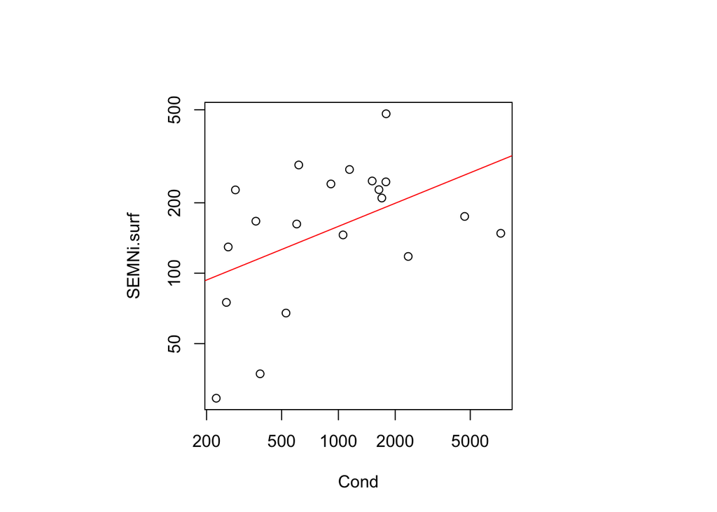

#### 2. REL_ABUND-CHEM correlations

- Table of correlation coefficients between relative abundances and all physicochemical and geochemical variables

|  | AVS.surf | AVS.deep | SEMFe.surf | SEMFe.deep | SEMMn.surf | SEMMn.deep | SEMNi.surf | SEMNi.deep | TotalFe.surf | TotalFe.deep | TotalMn.surf | TotalMn.deep | TotalNi.surf | TotalNi.deep | ASCFe.surf | ASCFe.deep | ASCMn.surf | ASCMn.deep | ASCNi.surf | ASCNi.deep | DITFe.surf | DITFe.deep | DITMn.surf | DITMn.deep | DITNi.surf | DITNi.deep | N.surf | N.deep | C.surf | … |
| --- | --- | --- | --- | --- | --- | --- | --- | --- | --- | --- | --- | --- | --- | --- | --- | --- | --- | --- | --- | --- | --- | --- | --- | --- | --- | --- | --- | --- | --- | --- |
| TAL | -3.0e-02 | -3.8e-04 | 3.9e-01 | 2.6e-01 | 3.8e-01 | -8.2e-02 | -4.0e-02 | 7.7e-02 | 7.6e-02 | -2.1e-02 | 4.8e-01 | -6.9e-02 | -1.0e-02 | 1.6e-01 | 3.2e-01 | 1.7e-01 | 3.4e-01 | -3.7e-02 | -1.9e-02 | -6.6e-02 | 8.8e-02 | 1.7e-01 | 2.7e-02 | 4.5e-03 | -4.9e-03 | 5.4e-02 | 4.1e-01 | 1.9e-01 | 2.5e-01 | … |
| GAM | 5.5e-02 | -7.5e-02 | -9.0e-02 | 1.0e-01 | -6.7e-02 | 1.2e-01 | -1.4e-01 | -1.4e-01 | 8.2e-02 | 1.3e-01 | -2.0e-02 | 1.6e-01 | -1.4e-01 | -1.5e-01 | 1.1e-01 | 5.5e-02 | 3.2e-02 | 7.5e-02 | -1.2e-01 | -1.5e-01 | 1.4e-01 | -5.6e-04 | 1.2e-01 | 1.7e-02 | -1.2e-01 | -1.4e-01 | 1.9e-02 | 5.4e-02 | -6.9e-02 | … |
| EPH | -1.6e-01 | -3.2e-01 | -4.8e-02 | -1.5e-01 | 5.6e-02 | 4.2e-01 | -3.0e-01 | -4.3e-01 | -1.4e-01 | -9.0e-02 | 6.8e-02 | 3.3e-01 | -3.8e-01 | -4.5e-01 | -1.2e-02 | -1.7e-02 | 1.2e-01 | 4.0e-01 | -2.0e-01 | -2.9e-01 | -1.1e-01 | 7.9e-04 | 5.6e-02 | 4.7e-01 | -3.2e-01 | -3.0e-01 | -1.9e-01 | -2.7e-01 | 9.8e-02 | … |
| HEP | -4.1e-02 | -3.6e-02 | 1.3e-01 | 1.2e-01 | 1.5e-01 | 1.2e-01 | -1.0e-01 | -1.1e-01 | -2.4e-02 | -9.9e-02 | 1.7e-01 | 9.5e-02 | -9.9e-02 | -1.1e-01 | 1.3e-01 | 5.8e-02 | 1.6e-01 | 1.7e-01 | -8.3e-02 | -9.4e-02 | -4.8e-02 | 3.2e-02 | 2.6e-02 | 1.7e-01 | -1.0e-01 | -1.1e-01 | 1.6e-01 | 8.8e-02 | 2.1e-01 | … |
| BAE | 2.9e-01 | -6.8e-02 | -1.8e-01 | 1.0e-01 | -5.3e-02 | 9.7e-02 | -1.1e-01 | -4.5e-02 | -8.0e-02 | -2.7e-02 | 7.9e-02 | 7.7e-02 | -7.5e-02 | -9.1e-02 | 5.5e-02 | -1.0e-02 | 4.9e-02 | 3.2e-02 | -9.6e-02 | -1.3e-01 | 2.6e-02 | -2.4e-02 | 1.2e-01 | 4.4e-02 | -5.9e-02 | -5.6e-02 | 5.1e-03 | 4.4e-02 | 4.7e-03 | … |
| CAE | -6.3e-02 | -2.1e-01 | 2.2e-01 | 3.1e-01 | 3.6e-01 | 4.1e-01 | -3.7e-01 | -4.2e-01 | 3.6e-02 | 5.0e-03 | 3.7e-01 | 4.1e-01 | -3.9e-01 | -4.4e-01 | 3.9e-01 | 9.3e-02 | 4.4e-01 | 4.1e-01 | -2.8e-01 | -3.9e-01 | 8.2e-02 | -5.8e-02 | 2.8e-01 | 2.4e-01 | -3.6e-01 | -4.5e-01 | 3.7e-01 | 2.2e-01 | 4.3e-01 | … |
| PSY | -7.1e-02 | -6.1e-02 | 2.2e-01 | 2.1e-01 | 2.5e-01 | 2.0e-01 | -1.8e-01 | -1.8e-01 | -4.1e-02 | -1.7e-01 | 3.0e-01 | 1.6e-01 | -1.7e-01 | -1.9e-01 | 2.3e-01 | 9.9e-02 | 2.7e-01 | 3.0e-01 | -1.4e-01 | -1.6e-01 | -8.2e-02 | 5.5e-02 | 4.5e-02 | 2.8e-01 | -1.8e-01 | -1.9e-01 | 2.8e-01 | 1.5e-01 | 3.7e-01 | … |
| BRA | -4.1e-02 | -3.6e-02 | 1.3e-01 | 1.2e-01 | 1.5e-01 | 1.2e-01 | -1.0e-01 | -1.1e-01 | -2.4e-02 | -9.9e-02 | 1.7e-01 | 9.5e-02 | -9.9e-02 | -1.1e-01 | 1.3e-01 | 5.8e-02 | 1.6e-01 | 1.7e-01 | -8.3e-02 | -9.4e-02 | -4.8e-02 | 3.2e-02 | 2.6e-02 | 1.7e-01 | -1.0e-01 | -1.1e-01 | 1.6e-01 | 8.8e-02 | 2.1e-01 | … |
| LEP | -4.1e-02 | -3.6e-02 | 1.3e-01 | 1.2e-01 | 1.5e-01 | 1.2e-01 | -1.0e-01 | -1.1e-01 | -2.4e-02 | -9.9e-02 | 1.7e-01 | 9.5e-02 | -9.9e-02 | -1.1e-01 | 1.3e-01 | 5.8e-02 | 1.6e-01 | 1.7e-01 | -8.3e-02 | -9.4e-02 | -4.8e-02 | 3.2e-02 | 2.6e-02 | 1.7e-01 | -1.0e-01 | -1.1e-01 | 1.6e-01 | 8.8e-02 | 2.1e-01 | … |
| POL | -3.2e-02 | -1.8e-01 | -1.3e-01 | 2.2e-01 | -1.1e-01 | 2.5e-01 | -2.9e-01 | -3.1e-01 | 2.4e-01 | 3.1e-01 | -5.0e-02 | 3.4e-01 | -3.2e-01 | -3.2e-01 | 2.5e-01 | 1.6e-01 | 7.3e-02 | 1.7e-01 | -2.6e-01 | -3.0e-01 | 3.4e-01 | 5.1e-03 | 2.9e-01 | 7.6e-03 | -2.7e-01 | -3.2e-01 | 6.0e-02 | 1.3e-01 | -1.7e-01 | … |
| HYD | -4.1e-02 | -3.6e-02 | 1.3e-01 | 1.2e-01 | 1.5e-01 | 1.2e-01 | -1.0e-01 | -1.1e-01 | -2.4e-02 | -9.9e-02 | 1.7e-01 | 9.5e-02 | -9.9e-02 | -1.1e-01 | 1.3e-01 | 5.8e-02 | 1.6e-01 | 1.7e-01 | -8.3e-02 | -9.4e-02 | -4.8e-02 | 3.2e-02 | 2.6e-02 | 1.7e-01 | -1.0e-01 | -1.1e-01 | 1.6e-01 | 8.8e-02 | 2.1e-01 | … |
| LIM | -4.4e-02 | 1.1e-01 | 3.2e-01 | -1.1e-01 | 1.7e-01 | 7.0e-02 | 1.6e-01 | 1.2e-01 | -1.3e-01 | -2.0e-02 | 1.3e-01 | -1.2e-01 | 5.3e-02 | 2.5e-01 | -9.6e-02 | 7.1e-03 | -1.0e-01 | 9.0e-02 | 1.3e-01 | 1.1e-01 | -1.5e-01 | 1.2e-01 | -3.7e-02 | 9.6e-02 | 6.1e-02 | 1.0e-01 | 5.7e-02 | 3.4e-01 | 9.7e-02 | … |
| PHR | -6.1e-02 | -1.2e-01 | -9.7e-02 | 1.7e-01 | -1.2e-02 | 5.8e-03 | -1.1e-01 | -4.6e-03 | 1.9e-01 | 2.0e-01 | 1.1e-01 | 8.6e-03 | -5.1e-02 | -2.2e-02 | 1.8e-01 | 2.1e-01 | 1.2e-01 | -4.5e-02 | -6.4e-02 | -4.0e-02 | 3.1e-01 | 1.7e-01 | 3.3e-01 | -6.1e-02 | -3.2e-02 | 1.5e-02 | 1.0e-02 | -1.1e-02 | -1.6e-01 | … |
| PHI | -4.0e-02 | 3.8e-02 | 2.4e-01 | -2.8e-02 | -1.4e-01 | -2.9e-01 | 1.0e-01 | 1.9e-01 | 1.5e-01 | 5.2e-02 | 3.6e-01 | -2.3e-01 | 7.7e-02 | 3.4e-01 | 4.4e-03 | -5.5e-02 | -1.9e-01 | -2.4e-01 | 7.7e-03 | 5.9e-02 | 2.1e-01 | -3.4e-02 | -1.1e-01 | -2.1e-01 | 1.2e-01 | 1.2e-01 | 1.4e-01 | -4.6e-02 | -1.5e-01 | … |
| COR | -1.2e-01 | -1.6e-01 | -6.2e-02 | 3.5e-03 | -2.5e-02 | 1.1e-01 | -1.2e-01 | -1.3e-01 | 1.2e-01 | 2.7e-01 | -7.3e-02 | 1.2e-01 | -1.3e-01 | -1.5e-01 | -4.7e-02 | -9.2e-02 | -4.5e-02 | -2.2e-02 | -9.0e-02 | -1.3e-01 | 2.2e-01 | -4.3e-02 | 4.1e-02 | -1.7e-01 | -1.0e-01 | -1.8e-01 | -1.3e-01 | -1.8e-01 | -1.2e-01 | … |
| ELM | -5.8e-02 | -5.0e-02 | 1.8e-01 | 1.7e-01 | 2.1e-01 | 1.7e-01 | -1.4e-01 | -1.5e-01 | -3.4e-02 | -1.4e-01 | 2.4e-01 | 1.3e-01 | -1.4e-01 | -1.6e-01 | 1.9e-01 | 8.1e-02 | 2.2e-01 | 2.4e-01 | -1.2e-01 | -1.3e-01 | -6.7e-02 | 4.5e-02 | 3.7e-02 | 2.3e-01 | -1.5e-01 | -1.5e-01 | 2.3e-01 | 1.2e-01 | 3.0e-01 | … |
| HAL | -3.9e-02 | -1.2e-03 | 1.5e-02 | -7.7e-02 | -6.0e-02 | -1.3e-01 | 7.7e-02 | 1.0e-01 | -1.8e-01 | -2.0e-01 | 1.0e-01 | -1.1e-01 | 7.8e-02 | 1.5e-01 | -8.5e-02 | -1.6e-01 | -1.1e-01 | -9.2e-02 | 9.2e-03 | 4.0e-02 | -1.7e-01 | -1.7e-01 | -1.8e-01 | -3.5e-02 | 3.8e-02 | 1.9e-02 | 5.8e-02 | 1.3e-02 | 1.0e-01 | … |
| GYR | -4.1e-02 | -3.6e-02 | 1.3e-01 | 1.2e-01 | 1.5e-01 | 1.2e-01 | -1.0e-01 | -1.1e-01 | -2.4e-02 | -9.9e-02 | 1.7e-01 | 9.5e-02 | -9.9e-02 | -1.1e-01 | 1.3e-01 | 5.8e-02 | 1.6e-01 | 1.7e-01 | -8.3e-02 | -9.4e-02 | -4.8e-02 | 3.2e-02 | 2.6e-02 | 1.7e-01 | -1.0e-01 | -1.1e-01 | 1.6e-01 | 8.8e-02 | 2.1e-01 | … |
| DYT | -3.9e-02 | 6.1e-02 | -1.7e-01 | -7.7e-02 | -4.1e-02 | -4.8e-01 | 2.3e-01 | 4.1e-01 | -1.1e-01 | -4.7e-02 | -3.8e-01 | -4.0e-01 | 3.8e-01 | 4.0e-01 | -1.6e-01 | 7.3e-02 | -9.1e-02 | -4.4e-01 | 1.5e-01 | 2.4e-01 | -2.3e-01 | 1.6e-01 | -5.1e-01 | -2.8e-01 | 2.4e-01 | 3.8e-01 | -1.9e-01 | -2.1e-01 | -2.1e-01 | … |
| CAR | -4.5e-02 | 1.1e-01 | 1.9e-02 | 1.2e-01 | -1.0e-01 | -3.6e-03 | -7.7e-02 | -5.5e-02 | 1.8e-01 | 1.6e-01 | -1.1e-01 | 3.8e-02 | -5.5e-02 | -7.3e-02 | 1.2e-01 | 7.7e-02 | -2.5e-02 | -1.3e-02 | -1.1e-01 | -8.9e-02 | 1.4e-01 | 8.9e-02 | 5.8e-02 | -4.1e-02 | -9.3e-02 | -6.4e-02 | 5.6e-02 | 5.9e-03 | -1.2e-01 | … |
| CHI | 5.0e-02 | 3.1e-01 | -5.2e-02 | -3.8e-02 | -2.4e-01 | -2.6e-01 | 2.1e-01 | 2.5e-01 | 1.1e-01 | 1.3e-01 | -2.8e-01 | -2.2e-01 | 2.1e-01 | 2.6e-01 | -2.2e-01 | -2.7e-02 | -3.6e-01 | -1.9e-01 | 6.1e-02 | 2.1e-01 | 4.1e-02 | -4.0e-02 | -4.8e-02 | -2.6e-01 | 1.6e-01 | 1.6e-01 | -1.9e-01 | 1.6e-01 | -2.4e-01 | … |
| CER | 1.2e-01 | -7.4e-02 | -3.9e-01 | -4.3e-01 | -2.0e-01 | -2.4e-01 | 4.6e-01 | 3.6e-01 | -2.3e-01 | -2.0e-01 | -2.7e-01 | -2.5e-01 | 4.7e-01 | 2.8e-01 | -3.6e-01 | -3.1e-01 | -1.8e-01 | -3.9e-01 | 5.9e-01 | 5.1e-01 | -2.2e-01 | -2.3e-01 | -2.6e-01 | -2.5e-01 | 5.5e-01 | 4.3e-01 | -1.5e-01 | -3.3e-01 | -9.7e-02 | … |
| CUL | -9.4e-03 | 3.3e-03 | -2.0e-01 | -1.9e-01 | -1.2e-01 | -1.2e-01 | 1.4e-01 | 1.4e-01 | -3.4e-01 | -2.6e-01 | -1.6e-01 | -1.1e-01 | 1.5e-01 | 1.2e-01 | -2.3e-01 | -2.5e-01 | -1.8e-01 | -1.4e-01 | 6.9e-02 | 9.7e-02 | -3.4e-01 | -2.6e-01 | -2.3e-01 | -6.1e-02 | 6.8e-02 | 4.1e-02 | -1.0e-01 | -1.8e-02 | 8.4e-02 | … |
| THA | -4.1e-02 | -3.6e-02 | 1.3e-01 | 1.2e-01 | 1.5e-01 | 1.2e-01 | -1.0e-01 | -1.1e-01 | -2.4e-02 | -9.9e-02 | 1.7e-01 | 9.5e-02 | -9.9e-02 | -1.1e-01 | 1.3e-01 | 5.8e-02 | 1.6e-01 | 1.7e-01 | -8.3e-02 | -9.4e-02 | -4.8e-02 | 3.2e-02 | 2.6e-02 | 1.7e-01 | -1.0e-01 | -1.1e-01 | 1.6e-01 | 8.8e-02 | 2.1e-01 | … |
| MUS | -3.9e-04 | 5.0e-02 | 1.9e-01 | -8.7e-02 | 1.5e-01 | -5.4e-02 | 9.1e-02 | 6.7e-02 | 1.8e-02 | -6.6e-03 | 1.0e-01 | 1.0e-02 | 7.6e-02 | 8.4e-02 | -1.7e-01 | -6.1e-02 | -1.3e-01 | -7.6e-02 | -3.2e-02 | 2.9e-02 | 6.4e-03 | -1.7e-01 | 9.8e-02 | -1.7e-01 | 5.9e-02 | 6.1e-02 | -1.5e-01 | -4.6e-02 | -7.3e-02 | … |
| TAB | -5.0e-02 | -9.0e-02 | 1.4e-01 | -1.4e-01 | 2.0e-01 | 2.1e-01 | -3.0e-04 | -4.1e-02 | -2.0e-01 | -1.3e-01 | 6.7e-02 | -3.3e-02 | -4.4e-02 | 1.2e-02 | -6.9e-02 | 8.4e-02 | 3.4e-02 | 2.7e-01 | 3.1e-02 | 2.9e-02 | -1.8e-01 | 6.4e-02 | 8.4e-02 | 1.5e-01 | -3.0e-02 | -5.1e-02 | -5.1e-03 | 2.0e-01 | 1.7e-01 | … |
| PLA | -8.6e-03 | 5.8e-01 | 2.4e-01 | 4.8e-02 | -1.4e-01 | -3.0e-01 | 1.6e-01 | 2.4e-01 | 1.9e-01 | 2.6e-02 | -2.5e-01 | -3.1e-01 | 2.5e-01 | 1.9e-01 | 1.6e-02 | -1.4e-02 | -1.7e-01 | -2.4e-01 | 1.7e-02 | 1.1e-01 | -3.3e-02 | 2.1e-01 | -1.7e-01 | -1.3e-01 | 7.9e-02 | 2.1e-01 | 1.1e-01 | -9.7e-02 | -1.2e-01 | … |
| VAL | -8.3e-02 | 3.6e-01 | 2.1e-01 | 4.9e-02 | 4.0e-02 | -3.0e-01 | 2.1e-01 | 3.3e-01 | 9.1e-02 | -1.3e-01 | -1.4e-01 | -2.8e-01 | 2.8e-01 | 2.6e-01 | 1.6e-02 | 5.1e-02 | -4.2e-02 | -1.9e-01 | 1.2e-01 | 2.1e-01 | -1.1e-01 | 1.7e-01 | -2.0e-01 | -1.3e-01 | 1.8e-01 | 2.8e-01 | 1.7e-01 | -2.5e-04 | -1.2e-02 | … |
| LYM | -6.2e-02 | -1.2e-01 | -8.7e-02 | 1.5e-01 | -8.6e-02 | 1.4e-01 | -1.9e-01 | -2.0e-01 | 1.8e-01 | 2.3e-01 | -4.4e-02 | 2.1e-01 | -2.0e-01 | -2.0e-01 | 1.7e-01 | 1.2e-01 | 4.7e-02 | 9.8e-02 | -1.8e-01 | -1.9e-01 | 2.3e-01 | 3.0e-02 | 1.7e-01 | 1.2e-03 | -1.8e-01 | -2.0e-01 | 3.1e-02 | 5.6e-02 | -1.2e-01 | … |
| UNI | -7.8e-02 | -8.0e-02 | 6.5e-02 | 5.6e-02 | 5.6e-02 | -1.3e-01 | 5.5e-02 | 1.5e-01 | 2.9e-02 | -6.3e-02 | 1.6e-01 | -2.1e-01 | 6.8e-02 | 2.0e-01 | -5.2e-02 | 9.3e-02 | -2.0e-02 | -5.4e-02 | 3.1e-02 | 8.1e-02 | 6.7e-03 | 1.9e-02 | 3.3e-02 | -1.4e-01 | 7.5e-02 | 8.5e-02 | 5.9e-02 | -7.0e-02 | -5.9e-02 | … |
| SPH | -4.3e-02 | 1.7e-01 | 5.8e-02 | -2.0e-02 | -1.5e-05 | -2.3e-01 | 2.3e-01 | 2.8e-01 | -8.5e-02 | -2.2e-01 | -7.9e-03 | -2.8e-01 | 2.9e-01 | 2.3e-01 | -2.8e-02 | -4.8e-02 | -4.1e-02 | -1.8e-01 | 2.1e-01 | 2.5e-01 | -1.2e-01 | 2.8e-02 | -7.2e-02 | -7.2e-02 | 2.1e-01 | 2.4e-01 | 1.1e-01 | 4.0e-03 | 7.9e-02 | … |
| COE | -4.1e-02 | -3.6e-02 | 1.3e-01 | 1.2e-01 | 1.5e-01 | 1.2e-01 | -1.0e-01 | -1.1e-01 | -2.4e-02 | -9.9e-02 | 1.7e-01 | 9.5e-02 | -9.9e-02 | -1.1e-01 | 1.3e-01 | 5.8e-02 | 1.6e-01 | 1.7e-01 | -8.3e-02 | -9.4e-02 | -4.8e-02 | 3.2e-02 | 2.6e-02 | 1.7e-01 | -1.0e-01 | -1.1e-01 | 1.6e-01 | 8.8e-02 | 2.1e-01 | … |
| GOM | -4.7e-02 | -7.6e-02 | -1.2e-01 | -1.1e-01 | -6.7e-02 | -1.1e-01 | 2.6e-01 | 3.1e-01 | -2.5e-02 | -6.0e-02 | 5.7e-03 | -4.0e-02 | 2.0e-01 | 2.4e-01 | -1.9e-01 | -9.8e-02 | -1.5e-01 | -1.3e-01 | 2.3e-01 | 3.1e-01 | -4.9e-02 | -6.6e-02 | 3.8e-02 | -1.2e-01 | 2.9e-01 | 2.9e-01 | -4.9e-02 | 9.9e-02 | -9.2e-02 | … |
| CAM | 1.4e-01 | -4.8e-02 | -6.1e-02 | 8.8e-02 | -1.7e-02 | 1.2e-01 | -1.2e-01 | -1.1e-01 | -3.0e-03 | 1.5e-02 | 4.7e-02 | 1.3e-01 | -1.2e-01 | -1.4e-01 | 8.7e-02 | 1.4e-02 | 5.9e-02 | 9.4e-02 | -1.0e-01 | -1.3e-01 | 4.7e-02 | -1.7e-02 | 7.9e-02 | 6.9e-02 | -9.5e-02 | -1.1e-01 | 4.6e-02 | 6.0e-02 | 3.0e-02 | … |
| SIA | -7.8e-02 | -1.4e-01 | -3.8e-01 | -3.1e-01 | 4.6e-02 | 2.5e-01 | -1.8e-01 | -1.9e-01 | -4.5e-01 | -2.6e-01 | -5.9e-02 | 3.3e-02 | -2.0e-01 | -1.8e-01 | -1.8e-01 | -1.7e-01 | 5.3e-02 | 6.5e-02 | -1.3e-01 | -1.6e-01 | -2.7e-01 | -4.5e-02 | 1.1e-01 | 7.4e-02 | -1.9e-01 | -1.7e-01 | -3.4e-01 | -2.2e-01 | -4.4e-02 | … |
| CP | 8.0e-02 | -4.0e-02 | -7.0e-02 | -3.5e-02 | 6.1e-02 | 1.1e-01 | -8.0e-02 | -1.8e-01 | 3.6e-02 | 2.2e-01 | -1.3e-01 | 2.2e-01 | -1.4e-01 | -1.8e-01 | 5.6e-02 | -1.2e-01 | 9.3e-02 | -3.2e-02 | -3.8e-02 | -1.5e-01 | 7.6e-02 | -2.6e-01 | 1.6e-01 | -1.9e-01 | -9.5e-02 | -2.1e-01 | 4.0e-02 | 1.1e-01 | 1.8e-02 | … |
| HI | -9.2e-02 | -6.9e-02 | 3.1e-01 | 2.5e-01 | 2.8e-01 | 2.0e-01 | -2.0e-01 | -1.9e-01 | -2.8e-02 | -2.0e-01 | 4.1e-01 | 1.6e-01 | -1.9e-01 | -1.8e-01 | 2.8e-01 | 1.1e-01 | 3.0e-01 | 3.2e-01 | -1.7e-01 | -1.9e-01 | -6.9e-02 | 6.2e-02 | 3.8e-02 | 3.1e-01 | -2.0e-01 | -2.1e-01 | 3.6e-01 | 1.7e-01 | 4.2e-01 | … |
| NE | 5.5e-01 | 3.2e-01 | -1.5e-02 | -1.9e-01 | -1.7e-01 | -4.1e-01 | 1.7e-01 | 2.1e-01 | -1.4e-01 | -1.4e-01 | -3.0e-01 | -3.0e-01 | 3.1e-01 | 3.2e-01 | -1.5e-01 | -7.8e-02 | -1.6e-01 | -2.9e-01 | 5.3e-02 | 1.5e-01 | -2.4e-01 | 1.8e-01 | -5.0e-01 | -8.6e-02 | 1.1e-01 | 3.3e-01 | -3.0e-01 | -3.2e-01 | -1.3e-01 | … |

#### 3. WATER+SED RDA model

- RDA model with forward-selected water and surface sediment variables. R squared increased ~5% and overall pattern is similar to separate models.
- Different iterations of the full model (not shown: 1. All water variables + all surface sediment variables; 2. Conductivity + pH + all surface sediment variables) either did not significantly explain community variation (1. p = 0.15) or produced a parsimonious (post-forward stepping) model identical to RDA*SURF* (2).

```
## $r.squared
## [1] 0.2090047
##
## $adj.r.squared
## [1] 0.1186052
```

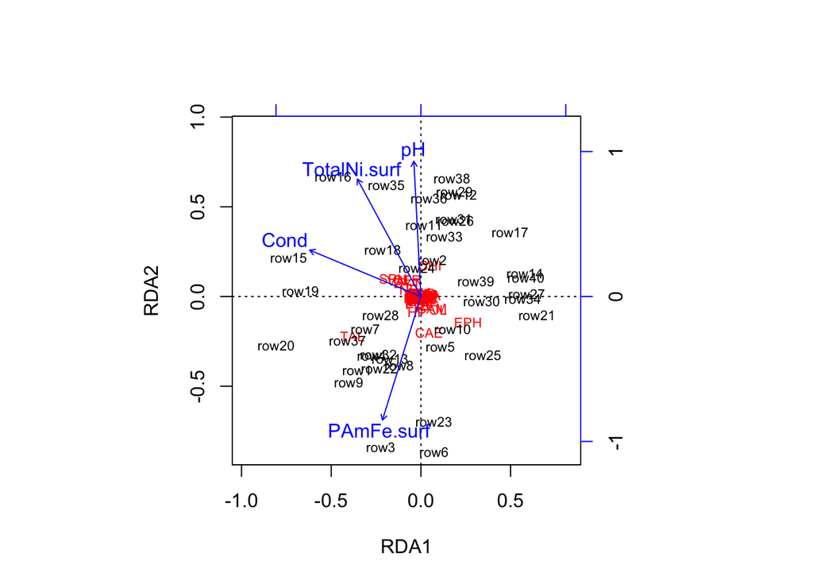

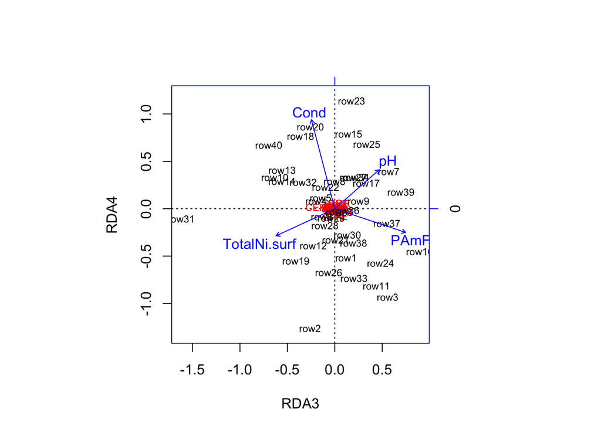

##### *Log-linear relationship between EPH relative abundance and conductivity*

- Log-linear relationship between Ephemeridae relative abundance and conductivity significant (p = 0.003), but no effect of mine location (same slope for Birchtree and Thompson mines)
- EPH~Cond graph to be added to SI as requested by reviewer 1

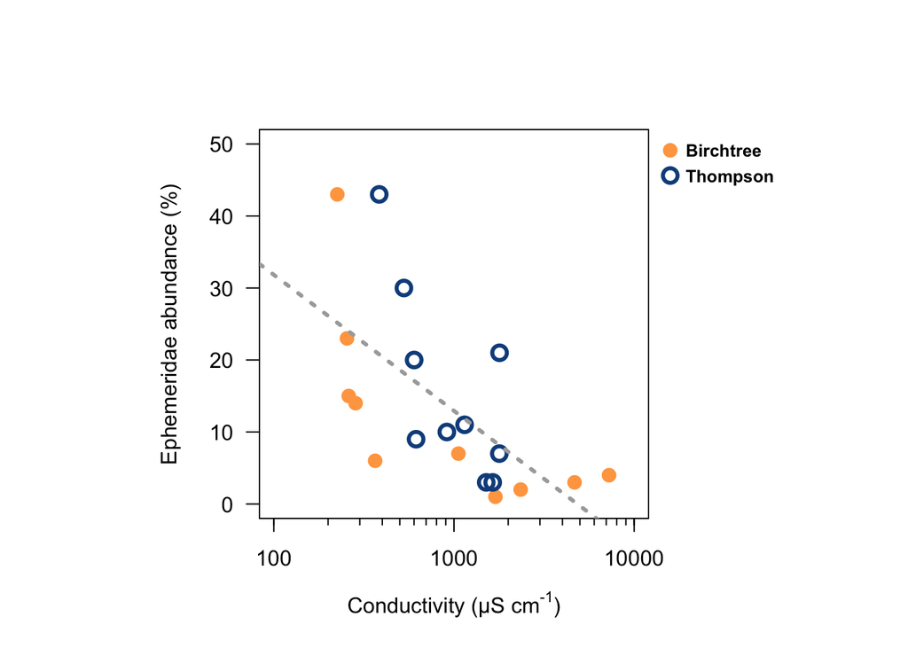

#### 4. SEM-AVS model w/o ‘outliers’

- Removed BE2 and WE2 data points which were <0 and calculated EC10 and EC20 for the data without the outliers. ECXX were well below the 130 umol/g benchmark (USEPA 2005).

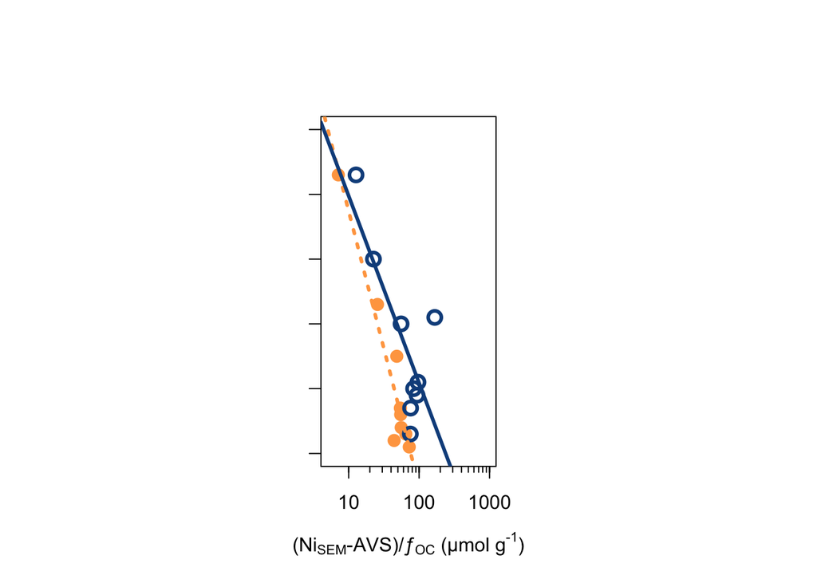

| *Log-Linear* Model | EC20 | RD.EC20 | EC10 | RD.EC10 |
| --- | --- | --- | --- | --- |
| Birchtree | 12 umol/g | 0.22 | 9 umol/g | 0.20 |
| Thompson | 15 umol/g |  | 11 umol/g |  |

#### 5. SEM-AVS outliers on all CR graphs

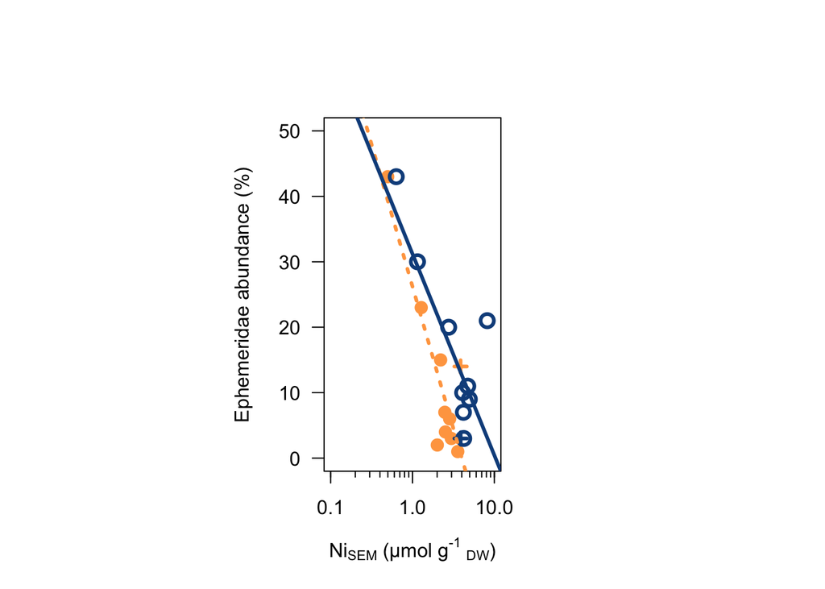

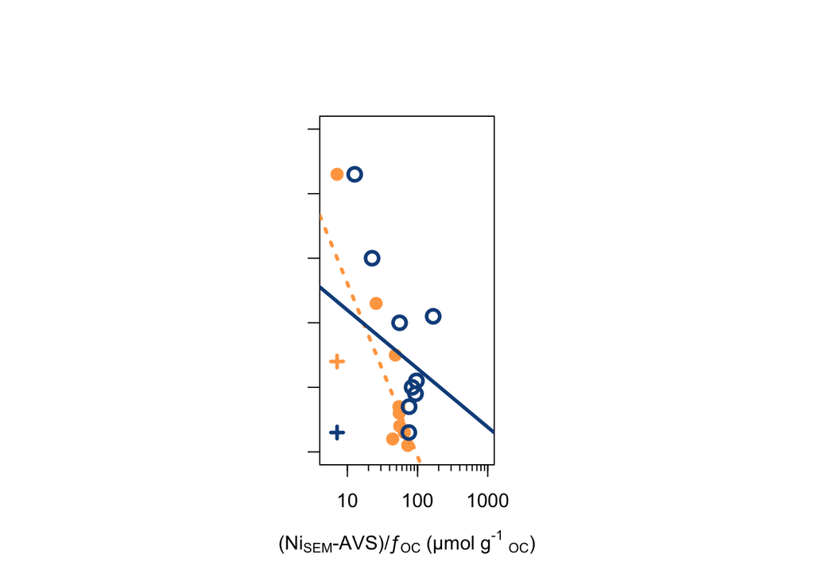

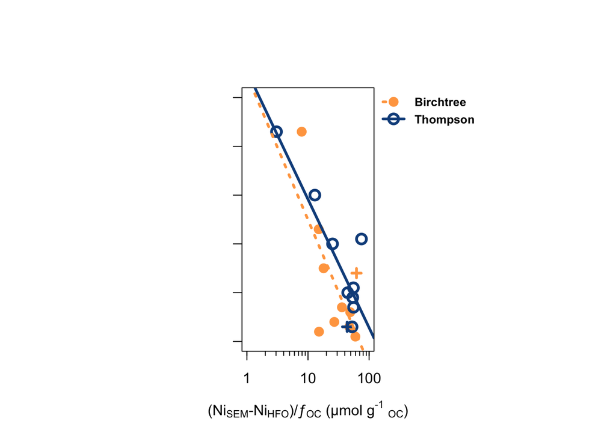

| *Log-Linear* Model | Birch EC20 (µmol/g) | Thompson EC20 (µmol/g) | RD.EC20 |
| --- | --- | --- | --- |
| Total Ni | 1.2 | 1.2 | 0.00 |
| SEM Ni | 0.6 | 0.8 | 0.28 |
| SEM-AVS/ƒOC (w/ ‘outliers’) | 4.9 | 0.4 | 1.70 |
| SEM-AVS/ƒOC (w/o ‘outliers’) | 12 | 15 | 0.22 |
| SEM-HFO/ƒOC | 4.8 | 6.3 | 0.27 |

#### 6. CRM TAL

```
##
## Call:
## lm(formula = REL_TAL ~ log(TotalNi.surf), data = chem.inv)
##
## Residuals:
##     Min      1Q  Median      3Q     Max
## -10.546  -8.071  -5.286   8.524  32.417
##
## Coefficients:
##                   Estimate Std. Error t value Pr(>|t|)
## (Intercept)          3.825      9.689   0.395    0.695
## log(TotalNi.surf)    1.068      2.019   0.529    0.600
##
## Residual standard error: 10.4 on 38 degrees of freedom
## Multiple R-squared:  0.007309,   Adjusted R-squared:  -0.01881
## F-statistic: 0.2798 on 1 and 38 DF,  p-value: 0.5999
```

```
##
## Call:
## lm(formula = REL_TAL ~ log(SEMNi.surf), data = chem.inv)
##
## Residuals:
##     Min      1Q  Median      3Q     Max
## -10.297  -8.056  -5.127   8.469  32.403
##
## Coefficients:
##                 Estimate Std. Error t value Pr(>|t|)
## (Intercept)       6.0208     6.5397   0.921    0.363
## log(SEMNi.surf)   0.6925     1.5356   0.451    0.655
##
## Residual standard error: 10.41 on 38 degrees of freedom
## Multiple R-squared:  0.005323,   Adjusted R-squared:  -0.02085
## F-statistic: 0.2034 on 1 and 38 DF,  p-value: 0.6546
```

```
##
## Call:
## lm(formula = REL_TAL ~ log(SEMAVSfOC.avg), data = chem.inv)
##
## Residuals:
##     Min      1Q  Median      3Q     Max
## -10.579  -8.006  -5.195   8.432  32.259
##
## Coefficients:
##                    Estimate Std. Error t value Pr(>|t|)
## (Intercept)          6.8547     4.4506   1.540    0.132
## log(SEMAVSfOC.avg)   0.7241     1.4822   0.489    0.628
##
## Residual standard error: 10.41 on 38 degrees of freedom
## Multiple R-squared:  0.006242,   Adjusted R-squared:  -0.01991
## F-statistic: 0.2387 on 1 and 38 DF,  p-value: 0.628
```

```
##
## Call:
## lm(formula = REL_TAL ~ log(NiSEMHFOfOC), data = chem.inv)
##
## Residuals:
##    Min     1Q Median     3Q    Max
## -9.329 -8.581 -5.150  8.281 32.821
##
## Coefficients:
##                  Estimate Std. Error t value Pr(>|t|)
## (Intercept)        8.3585     3.6177    2.31   0.0264 *
## log(NiSEMHFOfOC)   0.2234     1.3926    0.16   0.8734
## ---
## Signif. codes:  0 '***' 0.001 '**' 0.01 '*' 0.05 '.' 0.1 ' ' 1
##
## Residual standard error: 10.43 on 38 degrees of freedom
## Multiple R-squared:  0.0006768,  Adjusted R-squared:  -0.02562
## F-statistic: 0.02574 on 1 and 38 DF,  p-value: 0.8734
```

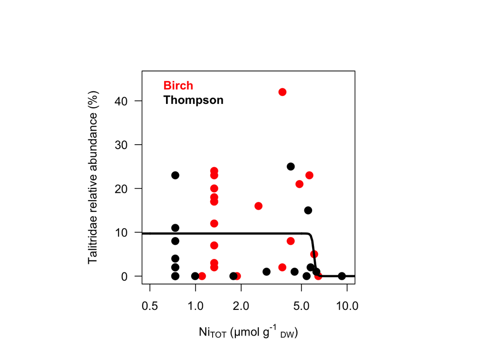

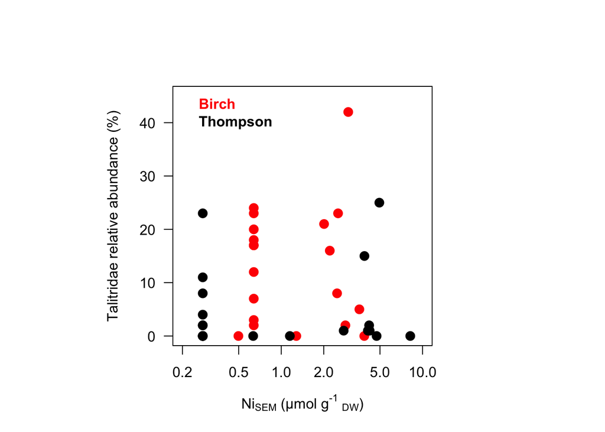

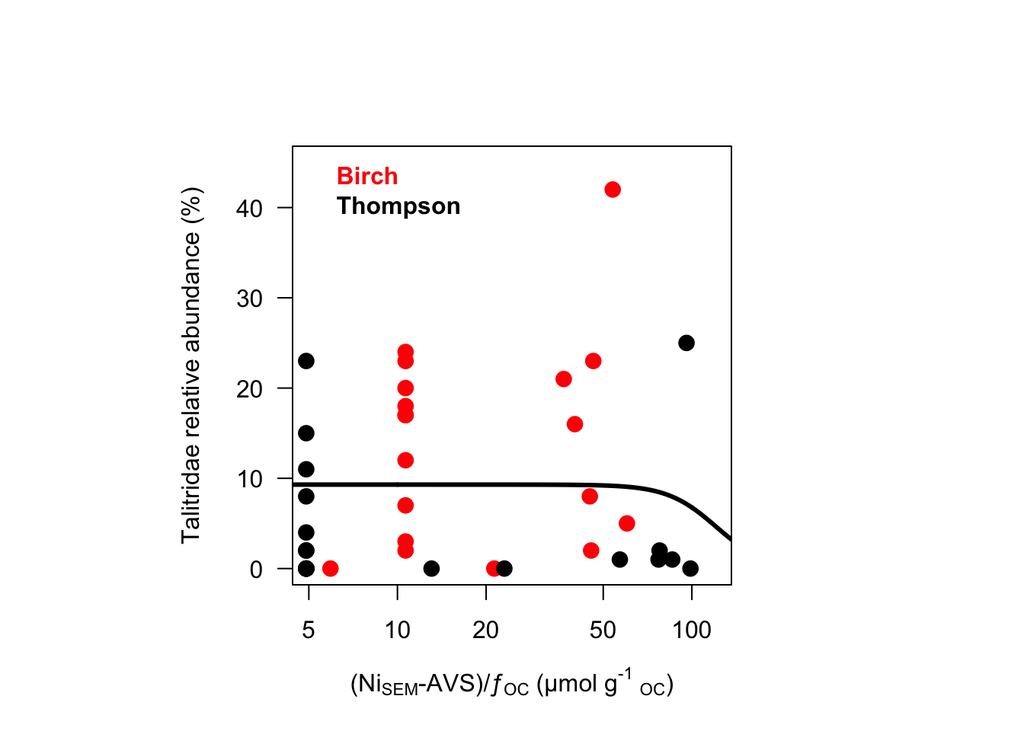

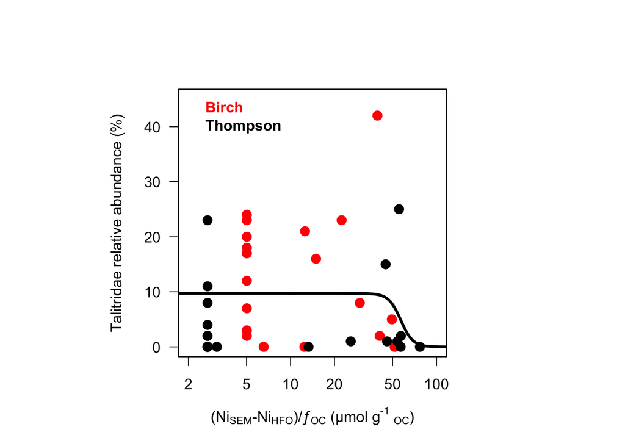

#### 7. Sigmoid CRM EPH

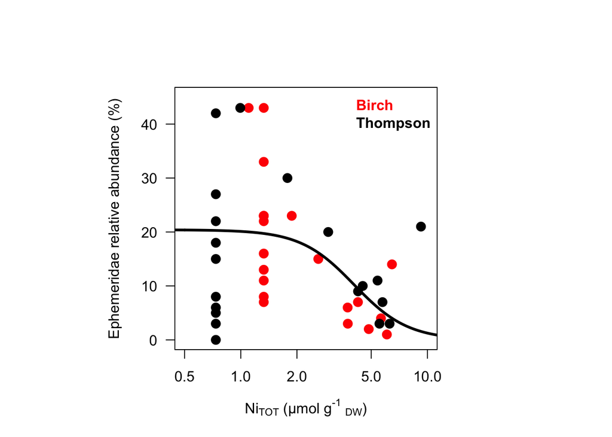

```
##
## Formula: REL_EPH ~ SSlogis(log10(TotalNi.surf.mol), Asym, xmid, scal)
##
## Parameters:
##      Estimate Std. Error t value Pr(>|t|)
## Asym  20.4027     3.1829   6.410 1.75e-07 ***
## xmid   0.6079     0.1281   4.743 3.11e-05 ***
## scal  -0.1440     0.1326  -1.086    0.285
## ---
## Signif. codes:  0 '***' 0.001 '**' 0.01 '*' 0.05 '.' 0.1 ' ' 1
##
## Residual standard error: 11.54 on 37 degrees of freedom
##
## Number of iterations to convergence: 21
## Achieved convergence tolerance: 5.271e-06
```

```
##     F ratio     P-value   R-squared
## 6.177471333 0.004843004 0.250328376
```

```
## [1] 2.570396
```

```
##               EC 20  Lower-bound (2.5%) Upper-bound (97.5%)
##                   3                   1                   4
```

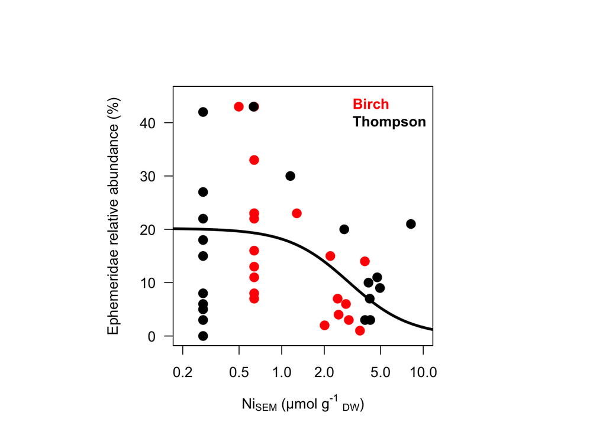

```
##
## Formula: REL_EPH ~ SSlogis(log10(SEMNi.surf.mol), Asym, xmid, scal)
##
## Parameters:
##      Estimate Std. Error t value Pr(>|t|)
## Asym  20.1820     3.6007   5.605 2.15e-06 ***
## xmid   0.4744     0.1762   2.692   0.0106 *
## scal  -0.2153     0.2207  -0.975   0.3357
## ---
## Signif. codes:  0 '***' 0.001 '**' 0.01 '*' 0.05 '.' 0.1 ' ' 1
##
## Residual standard error: 11.87 on 37 degrees of freedom
##
## Number of iterations to convergence: 27
## Achieved convergence tolerance: 8.231e-06
```

```
##    F ratio    P-value  R-squared
## 4.54170133 0.01722495 0.19710790
```

```
## [1] 1.513561
```

```
##               EC 20  Lower-bound (2.5%) Upper-bound (97.5%)
##                   1                   1                   3
```

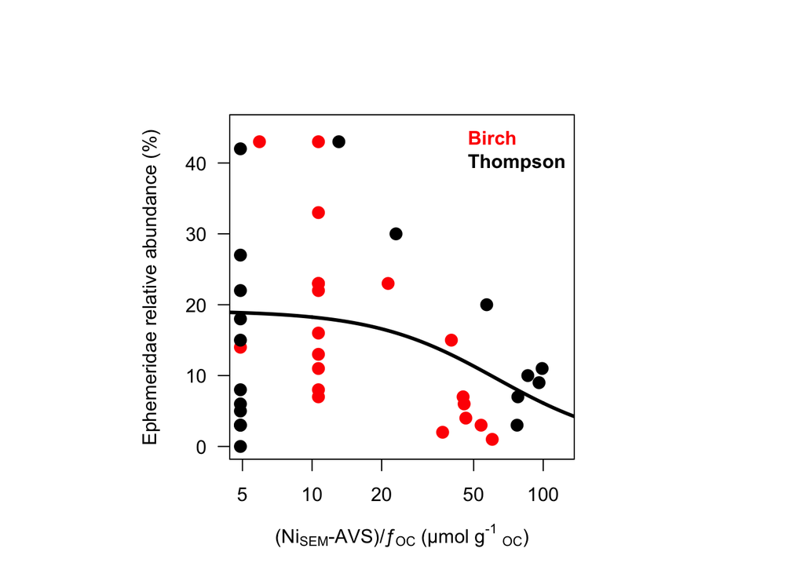

```
##
## Formula: REL_EPH ~ SSlogis(log10(SEMAVSfOC.avg), Asym, xmid, scal)
##
## Parameters:
##      Estimate Std. Error t value Pr(>|t|)
## Asym  19.1729     4.0290   4.759 2.97e-05 ***
## xmid   1.7975     0.2355   7.634 4.13e-09 ***
## scal  -0.2672     0.3218  -0.830    0.412
## ---
## Signif. codes:  0 '***' 0.001 '**' 0.01 '*' 0.05 '.' 0.1 ' ' 1
##
## Residual standard error: 12.23 on 37 degrees of freedom
##
## Number of iterations to convergence: 24
## Achieved convergence tolerance: 8.344e-06
```

```
##   F ratio   P-value R-squared
## 2.8596221 0.0700158 0.1338798
```

```
## [1] 26.91535
```

```
##               EC 20  Lower-bound (2.5%) Upper-bound (97.5%)
##                  27                   8                 127
```

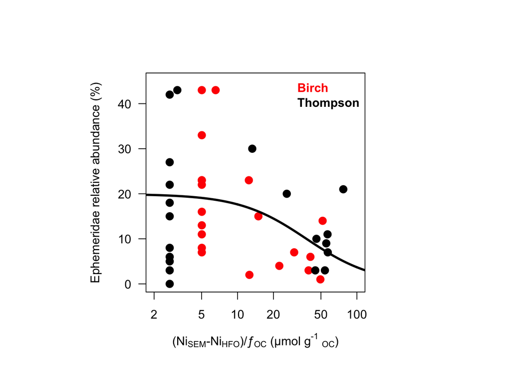

```
##
## Formula: REL_EPH ~ SSlogis(log10(NiSEMHFOfOC), Asym, xmid, scal)
##
## Parameters:
##      Estimate Std. Error t value Pr(>|t|)
## Asym  19.9403     4.1672   4.785 2.73e-05 ***
## xmid   1.5791     0.2462   6.415 1.73e-07 ***
## scal  -0.2842     0.3209  -0.886    0.382
## ---
## Signif. codes:  0 '***' 0.001 '**' 0.01 '*' 0.05 '.' 0.1 ' ' 1
##
## Residual standard error: 11.84 on 37 degrees of freedom
##
## Number of iterations to convergence: 12
## Achieved convergence tolerance: 3.724e-06
```

```
##    F ratio    P-value  R-squared
## 3.65163073 0.03570027 0.16484704
```

```
## [1] 15.48817
```

```
##               EC 20  Lower-bound (2.5%) Upper-bound (97.5%)
##                  15                   5                  40
```

| *Log-Logistic* Model | EC20 (µmol/g) |
| --- | --- |
| Total Ni | 2.6 |
| SEM Ni | 1.5 |
| SEM-AVS/ƒOC (w/ ‘outliers’) | 26.9 |
| SEM-HFO/ƒOC | 15.5 |